# hw3p2

### (e)(4 points) Fano factor

For each reaching angle, find the mean and variance of the spike counts across the 100 trials (using the same spike counts from part (c)). Plot the obtained mean and variance on the axes shown in Figure 1.14(A) in *TN*. There should be 8 points in this plot -- one per reaching angle.

```
[37.42 53.86 61.92 52.98 36.14 18.44 11.21 18.08]
```

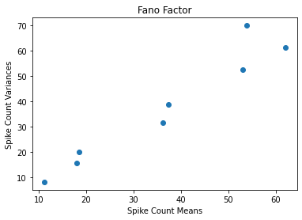

```python
## 2e

spike_count_means = np.mean(spike_counts, axis=1)
print(spike_count_means)

spike_count_vars = np.var(spike_counts, axis = 1)

plt.plot(spike_count_means, spike_count_vars, Marker = "o", linestyle = "none" )
plt.xlabel("Spike Count Means")
plt.ylabel("Spike Count Variances")
plt.title("Fano Factor")
plt.show()
```

#### Question:

Do these points lie near the 45 deg diagonal, as would be expected of a Poisson distribution?

#### Your answer: Yes

### (f) (5 points) Interspike interval (ISI) distribution

For each reaching angle, plot the normalized distribution of ISIs. Plot the 8 distributions around a circle, as in part (a). Fit an exponential distribution to each empirical distribution and plot it on top of the corresponding empirical distribution.

Please plot the empirical distribution as well as the fit

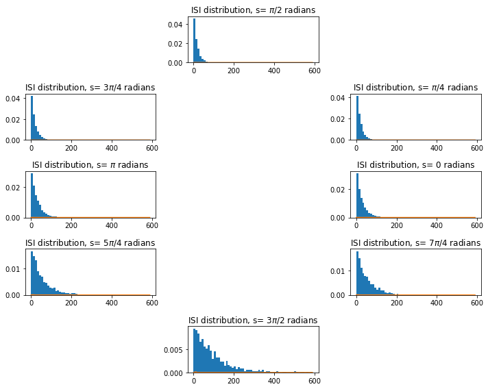

```python
## 2f FINAL ANSWER


## initial test for understanding


plt.figure(figsize=(10,8))
spikesunpacked = [[]for i in range(num_cons)]
isis_array = np.zeros(num_cons, dtype = list)
# let max ISI = 600 based on analysis of data

isis_max = 600
bin_centres_2f = np.arange(0, isis_max, 10)


for con in range(num_cons) :
    for rep in range(num_trials):

        plt.subplot(num_plot_rows,num_plot_cols,subplot_indx[con])


        spikesunpacked[con].extend(spike_times[con, rep])
        isis_array[con] = np.diff(spikesunpacked[con])


    plt.hist(isis_array[con], bins = bin_centres_2f, density = True)
    mean_isi = np.mean(isis_array[con])
    fit_exp = scipy.stats.expon(mean_isi)
    expon_pdf = fit_exp.pdf(bin_centres_2f)

    # I recognise I have not scaled the exponential correctly - to do: correct
    plt.plot(bin_centres_2f ,expon_pdf)


    plt.title('ISI distribution, s= '+ s_labels[con]+' radians')
    plt.tight_layout()
```

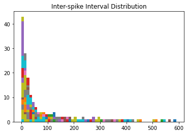

```python
## 2f


## INITIAL TEST FOR UNDERSTANDING


for con in range(num_cons) :
    for rep in range(num_trials):

        isi_test = np.diff(spike_times[con,rep])
        bins2f = np.arange(0, 600, 10)
        # print(isi_test)
        plt.hist(isi_test, bins2f)
        plt.title('Inter-spike Interval Distribution')
```

#### Question:

Are the empirical distributions well-fit by exponential distributions?

### (g) (5 points) Coefficient of variation ($C_V$)

For each reaching angle, find the average ISI and $C_V$ of the ISIs. Plot the resulting values on the axes shown in Figure 1.16 in *TN*. There should be 8 points in this plot.

```
(8,)
[52.82817918 78.89446167  6.18168684 ... 11.51698786 30.78871957
  9.73491553]
-------
0.20633657176808395
[0.20633657 0.17327531 0.15438427 0.18618816 0.28345941 0.54789421
 0.88992617 0.47339882]
[164.75331609 134.75643613 126.84782776 136.11361454 168.97998842
 231.05507818 301.02627751 225.70712557]
testesttest: [0.20633657 0.17327531 0.15438427 0.18618816 0.28345941 0.54789421
 0.88992617 0.47339882]
```

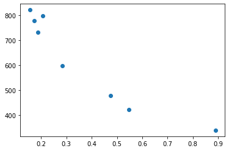

```python
#2g

# coefficient of variation = standard deviation / mean

mean_isi = np.zeros(num_cons)
std_isi = np.zeros(num_cons)
coef_v = np.zeros(num_cons)
mean_2_isi = np.zeros(num_cons)
std_2_isi = np.zeros(num_cons)


print(isis_array.shape)
print(isis_array[0])
print("-------")
print(np.mean(isis_array[0]))


for con in range(num_cons):
    mean_isi[con] = np.mean(isis_array[con])
    std_isi[con] = np.std(isis_array[con])
    coef_v[con] = std_isi[con] / (mean_isi[con])

print(mean_isi)
print(std_isi)

plt.plot(mean_isi, coef_v, marker = 'o', linestyle = 'none')
#plt.plot(coef_v, mean_isi, marker = 'x', linestyle = 'none')


print("testesttest:", mean_isi)


## this unity should be reversed -- If I had time what I would do is: create a 8x100 numpy array composed of 8x100 lists.
# each list would be a list of ISIs
# I would take the mean and standard deviation of each list, creating a new array
# then I would take the mean and standard deviation across each condition, and plot that - that should look like unity as we were expecting
```

#### Question:

Do the $C_V$ values lie near unity, as would be expected of a Poisson process?

#### Your answer:

Not right now, but I know what I need to do to make it look like unity.